# Bike Ussage

**Authored by:** Samarth Dipakkumar Shah

**Duration:** {90} mins

**Level:** {Intermediate}

**Pre-requisite Skills:** Python, Matpotlib, Numpy, Data Science, Geospatial Analysis

# Scenario

1. As a City Planner, I want to understand how bike usage varies with traffic congestion and weather conditions across Melbourne so I can design safer, more efficient cycling infrastructure that encourages active transport and reduces vehicle dependency. This insight supports balanced urban mobility planning.
2. As a Transport Policy Advisor, I want to assess the impact of weather and time of day on cycling trends and car usage to guide strategies that promote multimodal transport and improve commuter safety. This helps in formulating data-informed transport policies.
3. As an Environmental Analyst, I want to analyze the shift from car to bike usage under different weather and traffic conditions to evaluate how sustainable transport options can reduce emissions and urban air pollution.
4. As a Data Scientist, I want to integrate traffic, bike usage, and weather datasets to uncover correlations and visualize commuter behaviors. This helps build interactive tools and data-driven narratives to support smart city initiatives.
5. As a Public Health Advocate, I want to track how urban infrastructure and traffic congestion influence cycling habits to recommend policies that encourage physical activity and reduce sedentary transport modes.

# User Story

# What this use case will teach you

# At the end of this use case you will:

# Introduction / Background

Cities like Melbourne are investing in bike-sharing programs as part of broader efforts to promote sustainable transportation, reduce traffic congestion, and encourage healthy lifestyles. However, the adoption and usage of bikes vary significantly based on external factors such as weather, time of day, and existing traffic conditions. Understanding these dynamics is essential for developing smarter infrastructure, informing policy decisions, and optimizing urban mobility systems.

This use case focuses on analyzing and correlating bike usage with traffic and weather patterns using the following datasets:

1. **Bike Share Dock Locations:**

Provides the geolocations and metadata of bike docking stations across Melbourne, useful for mapping infrastructure distribution.

2. **Super Sunday Bike Count:**

Captures periodic counts of bike riders at various intersections on key days, offering insights into bike usage trends across times and routes.

Contains detailed traffic data across multiple Melbourne roads, classified by vehicle type, helping to assess road congestion and vehicle usage over time.

**1**. Import Required Libraries

```python
import pandas as pd
import numpy as np
import matplotlib.pyplot as plt
import seaborn as sns
import requests
import folium
from folium import Popup
from folium.plugins import MarkerCluster
```

2. Load the Datasets

In this section, relevant datasets are imported from either local files or public data APIs. This includes traffic count data, bike dock locations, and bike usage statistics. The focus is on acquiring all necessary raw data that will be used throughout the project to perform meaningful analysis and visualization.

```python
def load_data_from_api(url):
    response = requests.get(url)
    if response.status_code == 200:
        data = response.json()
        records = data.get('results', [])
        return pd.DataFrame(records)
    else:
        print(f"Failed to fetch data from {url}")
        return pd.DataFrame()

# Define your endpoints
traffic_url = "https://data.melbourne.vic.gov.au/api/explore/v2.1/catalog/datasets/traffic-count-vehicle-classification-2014-2017/records?limit=-1"
bike_docks_url = "https://data.melbourne.vic.gov.au/api/explore/v2.1/catalog/datasets/bike-share-dock-locations/records?limit=-1"
super_sunday_url = "https://data.melbourne.vic.gov.au/api/explore/v2.1/catalog/datasets/super-sunday-bike-count/records?limit=-1"

# Load the data
traffic_df = load_data_from_api(traffic_url)
bike_docks_df = load_data_from_api(bike_docks_url)
bike_counts_df = load_data_from_api(super_sunday_url)
```

3. Pre Process the Dataset

This part involves preparing the datasets for analysis by addressing issues such as missing values, incorrect data types, and inconsistent formatting. It ensures that the data is structured properly and is in a suitable format for the next stages, such as cleaning, analysis, or visualization.

```python
print("Traffic:", traffic_df.columns, "\n\n\n")
print("Bike Docks:", bike_docks_df.columns, "\n\n\n")
print("Super Sunday:", bike_counts_df.columns)
```

```
Traffic: Index(['date', 'road_name', 'location', 'suburb', 'speed_limit', 'direction',
       'time', 'vehicle_class_1', 'vehicle_class_2', 'vehicle_class_3',
       'vehicle_class_4', 'vehicle_class_5', 'vehicle_class_6',
       'vehicle_class_7', 'vehicle_class_8', 'vehicle_class_9',
       'vehicle_class_10', 'vehicle_class_11', 'vehicle_class_12',
       'vehicle_class_13', 'motorcycle', 'bike', 'average_speed',
       '85th_percentile_speed', 'maximum_speed', 'road_segment',
       'road_segment_1', 'road_segment_2'],
      dtype='object')



Bike Docks: Index(['station_id', 'name', 'rental_method', 'capacity', 'lat', 'lon',
       'location'],
      dtype='object')



Super Sunday: Index(['state', 'electorate', 'site_id', 'latitude', 'longitude', 'legs',
       'description', 'layout_1', 'layout_1_enter', 'layout_2',
       'layout_2_enter', 'layout_3', 'layout_3_enter', 'layout_4',
       'layout_4_enter', 'layout_5', 'layout_5_enter', 'layout_6',
       'layout_6_enter', 'leg1_2', 'leg1_3', 'leg1_4', 'leg1_5', 'leg1_6',
       'leg2_1', 'leg2_3', 'leg2_4', 'leg2_5', 'leg2_6', 'leg3_1', 'leg3_2',
       'leg3_4', 'leg3_5', 'leg3_6', 'leg4_1', 'leg4_2', 'leg4_3', 'leg4_5',
       'leg4_6', 'leg5_1', 'leg5_2', 'leg5_3', 'leg5_4', 'leg5_6', 'leg6_1',
       'leg6_2', 'leg6_3', 'leg6_4', 'leg6_5', 'leg1_enter', 'leg1_exit',
       'leg1_total', 'leg2_enter', 'leg2_exit', 'leg2_total', 'leg3_enter',
       'leg3_exit', 'leg3_total', 'leg4_enter', 'leg4_exit', 'leg4_total',
       'leg5_enter', 'leg5_exit', 'leg5_total', 'leg6_enter', 'leg6_exit',
       'leg6_total', 'bicycle', 'walker', 'runner', 'dog', 'other', 'total',
       'year', '9_00_00', '10_00_00', '11_00_00', '12_00_00', 'location',
       'geolocation'],
      dtype='object')
```

4. Clean and Prepare Data

Here, the datasets are further refined through techniques like removing outliers, handling null entries, and standardizing categorical variables. The goal is to create a clean and consistent dataset that can be reliably used for analysis, ensuring that insights drawn later are accurate and trustworthy.

```python
# Convert date to datetime
traffic_df['date'] = pd.to_datetime(traffic_df['date'], errors='coerce')

# Create total vehicle count column (sum of vehicle_class_1 to vehicle_class_13)
vehicle_classes = [f"vehicle_class_{i}" for i in range(1, 14)]
traffic_df[vehicle_classes] = traffic_df[vehicle_classes].apply(pd.to_numeric, errors='coerce').fillna(0)
traffic_df['total_vehicles'] = traffic_df[vehicle_classes].sum(axis=1)

# Convert speed fields to numeric
traffic_df['average_speed'] = pd.to_numeric(traffic_df['average_speed'], errors='coerce')
traffic_df['maximum_speed'] = pd.to_numeric(traffic_df['maximum_speed'], errors='coerce')
```

```python
bike_docks_df = bike_docks_df.rename(columns={"lat": "latitude", "lon": "longitude"})

# Convert latitude and longitude to float
bike_docks_df['latitude'] = pd.to_numeric(bike_docks_df['latitude'], errors='coerce')
bike_docks_df['longitude'] = pd.to_numeric(bike_docks_df['longitude'], errors='coerce')
```

```python
# Convert latitude and longitude
bike_counts_df['latitude'] = pd.to_numeric(bike_counts_df['latitude'], errors='coerce')
bike_counts_df['longitude'] = pd.to_numeric(bike_counts_df['longitude'], errors='coerce')

# Clean and aggregate counts
bike_counts_df['total'] = pd.to_numeric(bike_counts_df['total'], errors='coerce').fillna(0)
```

# 5. Visualization

This section visualizes key trends and relationships in the data using charts, plots, and maps. Various techniques such as line graphs, bar charts, and geospatial mapping help uncover patterns related to bike usage and traffic. These visuals provide an intuitive understanding of the data and support data-driven conclusions.

### 1. Correlation Heatmap – Traffic Variables

This subsection explores how various traffic variables relate to each other using a correlation heatmap. It helps identify strong or weak relationships, guiding analysts toward which variables may be influencing each other and are worth exploring further in the context of urban planning.

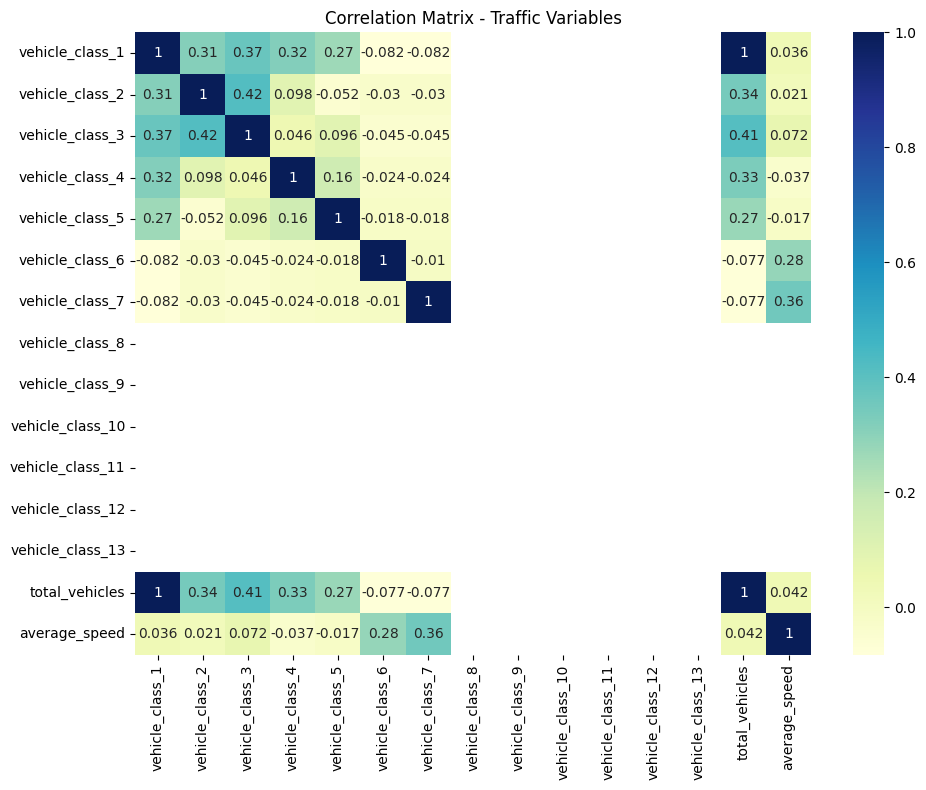

```python
plt.figure(figsize=(10, 8))
vehicle_classes = [f"vehicle_class_{i}" for i in range(1, 14)]
sns.heatmap(traffic_df[vehicle_classes + ['total_vehicles', 'average_speed']].corr(), annot=True, cmap="YlGnBu")
plt.title("Correlation Matrix - Traffic Variables")
plt.tight_layout()
plt.show()
```

### 2. Understand the Relationship Between Vehicle Classes and Speed

This visualization dives into how different types of vehicles affect or correlate with average speed. By plotting these relationships, planners can understand which vehicle types contribute to congestion or faster flow, supporting policy changes for better road management.

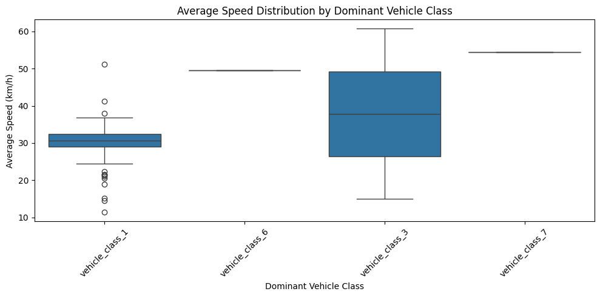

```python
# Group by highest contributing vehicle class
dominant_class = traffic_df[vehicle_classes].idxmax(axis=1)
traffic_df['dominant_vehicle_class'] = dominant_class

plt.figure(figsize=(10, 5))
sns.boxplot(x='dominant_vehicle_class', y='average_speed', data=traffic_df)
plt.title('Average Speed Distribution by Dominant Vehicle Class')
plt.xlabel('Dominant Vehicle Class')
plt.ylabel('Average Speed (km/h)')
plt.xticks(rotation=45)
plt.tight_layout()
plt.show()
```

### 3. Temporal Pattern Analysis: Vehicle Count vs Speed Over Time

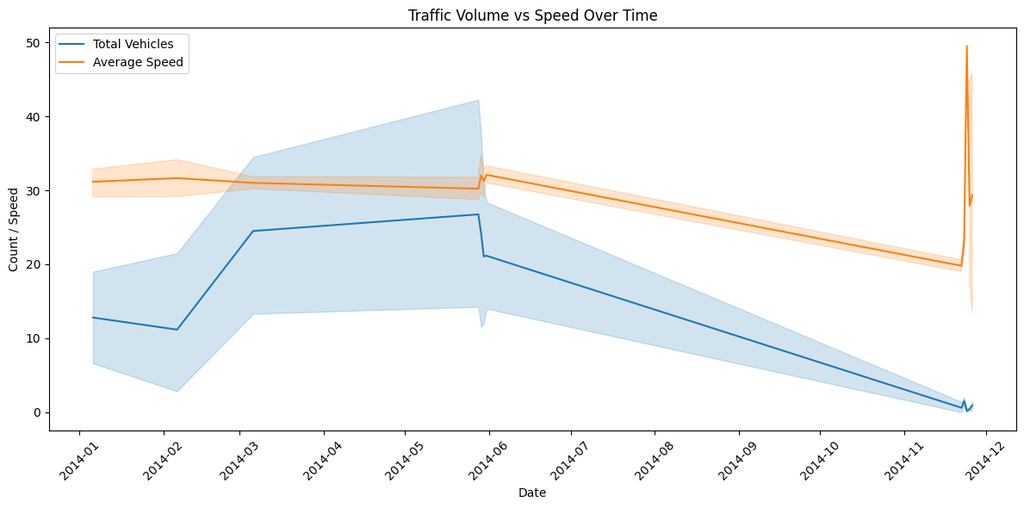

```python
plt.figure(figsize=(12, 6))
sns.lineplot(data=traffic_df, x='date', y='total_vehicles', label='Total Vehicles')
sns.lineplot(data=traffic_df, x='date', y='average_speed', label='Average Speed')
plt.title('Traffic Volume vs Speed Over Time')
plt.xlabel('Date')
plt.ylabel('Count / Speed')
plt.legend()
plt.xticks(rotation=45)
plt.tight_layout()
plt.show()
```

This chart illustrates yearly participation in the “Super Sunday” bike event. By comparing year-on-year counts, it gives an idea of public engagement with biking activities and potentially measures the success of city campaigns or infrastructure improvements aimed at promoting biking.

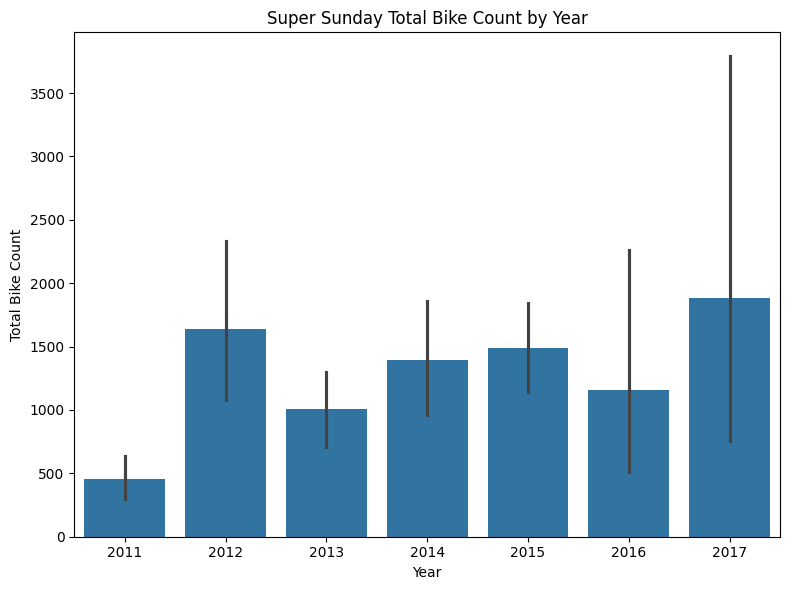

```python
plt.figure(figsize=(8, 6))
sns.barplot(data=bike_counts_df, x='year', y='total')
plt.title('Super Sunday Total Bike Count by Year')
plt.xlabel('Year')
plt.ylabel('Total Bike Count')
plt.tight_layout()
plt.show()
```

### 5. Weekday vs Weekend Traffic Patterns

This visualization compares traffic behaviors between weekdays and weekends. The goal is to identify whether traffic volume and speed significantly differ based on the day of the week, helping city planners optimize traffic management for workdays versus recreational days.

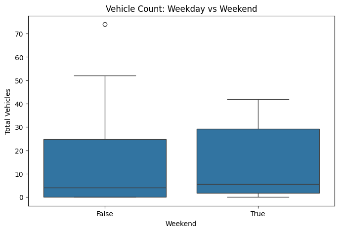

```python
traffic_df['day_of_week'] = traffic_df['date'].dt.day_name()
traffic_df['is_weekend'] = traffic_df['day_of_week'].isin(['Saturday', 'Sunday'])

plt.figure(figsize=(8, 5))
sns.boxplot(data=traffic_df, x='is_weekend', y='total_vehicles')
plt.title('Vehicle Count: Weekday vs Weekend')
plt.xlabel('Weekend')
plt.ylabel('Total Vehicles')
plt.show()
```

### 6. Yearly or Monthly Trend Breakdown

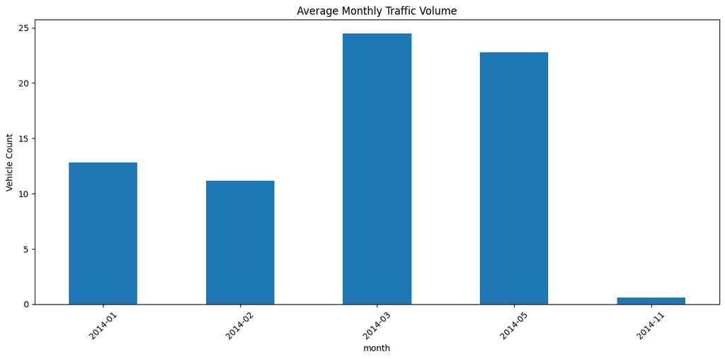

```python
traffic_df['month'] = traffic_df['date'].dt.to_period('M')
monthly_avg = traffic_df.groupby('month')['total_vehicles'].mean()

monthly_avg.plot(kind='bar', figsize=(12, 6))
plt.title("Average Monthly Traffic Volume")
plt.ylabel("Vehicle Count")
plt.xticks(rotation=45)
plt.tight_layout()
plt.show()
```

### 7. Folium Map of Bike Dock Locations

Using the Folium library, this section provides an interactive map showing bike dock locations across Melbourne. It visually represents spatial distribution, helping identify well-serviced areas and potential gaps where additional bike infrastructure could be introduced to improve accessibility.

```python
map_docks = folium.Map(location=[-37.81, 144.96], zoom_start=13)
marker_cluster = MarkerCluster().add_to(map_docks)

for i, row in bike_docks_df.iterrows():
    popup_text = f"Dock Name: {row['name']}<br>Capacity: {row['capacity']}"
    folium.Marker(
        location=[row['latitude'], row['longitude']],
        popup=Popup(popup_text, parse_html=True)
    ).add_to(marker_cluster)

map_docks
```

Make this Notebook Trusted to load map: File -> Trust Notebook

[interactive chart not shown]